# CurrentWorkingDraftCrypto

Anika Larson

5/29/2016

For this risk estimate, we will use mcmodel and evalmcmod from the [mc2d](https://cran.r-project.org/web/packages/mc2d/index.html) package.

```r
# Load packages.
library(mc2d)
library(data.table)
```

### Define variables

Set the number of simulations for the variability and uncertainty dimensions.

```r
nsv <- 401
nsu <- 108
ndvar(nsv)  # Variability
```

```
## [1] 401
```

```r
ndunc(nsu)   # Uncertainty
```

```
## [1] 108
```

```r
rdv <- (nsu/3)
cwv <- (nsu/4)
ns <- nsu * nsv
```

The *mc2d* functions will set `nsv` to `ndvar()` and `nsu` to `ndunc()` by default. Alternatively, we could supply these values to the *mc2d* model functions when we call them.

Define the variables we will use to set the `seed` for random sampling and the number of `digits` for `print()` statements.

```r
seed <- 1
digits <- 5
```

Introducing the bootstrapped dose-response data, fread command and sampling from Brian:

```r
alpha <- fread("output_dupont_crypto/alphalist.csv", sep = ',')
n50 <- fread("output_dupont_crypto/N50list.csv", sep = ',')
cdr <- merge(alpha,n50, by = "V1")
scdr <- cdr[sample(nrow(cdr), nsu, replace = TRUE), list(alpha, N50)] #sampling rows in the dose-response bootstrapped table equal to the number of simulations in the uncertainty dimension, aka NSU
```

Leaving that ^ for convenience, but since what we really want is a k-value list made of samples from the three different dose-response estimates (Dupont, Tamu, and UCP):

```r
k_dup <- fread("output_dupont_crypto/klist_dupont.csv", sep = ',')
gdrkD <- k_dup[sample(nrow(k_dup), rdv, replace = TRUE), list(k)] #sampling rows in the dose-response bootstrapped table equal to 1/3 the number of simulations in the uncertainty dimension, aka NSU
k_tamu <- fread("output_tamu_crypto/klist_tamu.csv", sep = ',')
gdrkT <- k_tamu[sample(nrow(k_tamu), rdv, replace = TRUE), list(k)]
k_ucp <- fread("output_UCP_crypto/klist_ucp.csv", sep = ',')
gdrkU <- k_ucp[sample(nrow(k_ucp), rdv, replace = TRUE), list(k)]
kval <- unlist(c(gdrkD,gdrkT,gdrkU))
```

Sampling from the Cryptosporidium custom distribution estimates:

```r
cw.vlg <- fread("conc_data_aggreg.csv", sep = ',')
cw.vl.samp <- sample(cw.vlg[,c(oocysts)], nsu, replace = TRUE)
```

Sampling from the distribution of the estimates of Crypto reduction by porous ceramic filtration:

```r
  #pfc_reduc set using the distribution
  gcfilt <- fread("cer_filts/CerFiltCrypto.csv", sep = ',')
  colnames(gcfilt) <- c("trial","logr")
  gcfilt$reduc <- (1 - (10^(-gcfilt$logr)))
  pfc_reduc2 <- gcfilt[sample(nrow(gcfilt), nsu, replace = TRUE), list(reduc)]
```

Sampling from the daily hosing exposure estimates distribution:

```r
  #Creating a distribution for hosing
  hose <- fread("exp_params/Hosing.csv", sep = ',')
  colnames(hose) <- c("trial","num", "mL")
  hose$hose_exp1 <- (hose$num * hose$mL)
  hose_exp <- hose[sample(nrow(hose), nsu, replace = TRUE), list(hose_exp1)]
```

Sampling from the daily showering exposure estimates distribution:

```r
  #Creating a distribution for showering
  shower <- fread("exp_params/Showers.csv", sep = ',')
  colnames(shower) <- c("trial","num", "mL")
  shower$shower_exp1 <- (shower$num * shower$mL)
  shower_exp <- shower[sample(nrow(shower), nsu, replace = TRUE), list(shower_exp1)]
```

### Define exposure model

Within the mcmodel function, use mcstoc to define “mc nodes” for each component of the model.

For each stochastic variable, use the `mcstoc()` function to create a “mcnode”, supply a probability function, the node type as “V” for variability or “U” for uncertainty, and any additional parameters to be passed to the probability function.

For deterministic variables, create nodes with the `mcdata()` function using the “0” type.

We will model the deterministic factors as uniform probablity distributions.

The last statement makes an “mc” object using the mc function.

```r
# Define an exposure model for evaluation by evalmcmod().
expo.mod1 <- mcmodel({
  # Values from Example 6.18 from Quantitative Microbial Risk Assessment,
  # 2nd Edition by Charles N. Haas, Joan B. Rose, and Charles P. Gerba.
  # (Wiley, 2014), pp. 215-216. Other fictitious values are noted below.

   # Cistern water viral loading (viruses/L):
  cw.vl1 <- mcdata(cw.vl.samp, type = "U")
  cw.vl2 <- mcstoc(rempiricalD, type = "V", values = cw.vl.samp)
  cw.vl <- cw.vl2

  # Water consumption (L/day):
  dw.ing1 <- mcdata(1.466, type = "U")
  dw.ing2 <- mcstoc(rpois, type = "V", lambda = 1.466)
  dw.ing <- dw.ing1

  # Hosing per event ingestion rate (L/event): worst case estimate = 10mL or .01L per day
  hose.perevent <- mcdata(.01, type = "U")
  hose.perevent.dis <- mcdata(hose_exp$hose_exp1, type = "U")
  #Daily hosing exposure sampling from distribution
  daily_hose_exp <- mcstoc(rempiricalD, type = "V", values = hose_exp$hose_exp1)
  hosing <- daily_hose_exp

   # Showering per event ingestion rate (L/event): worst case estimate = 10mL or .01L per day
  shower.perevent <- mcdata(.01, type = "U")
  shower.perevent.dis <- mcdata(shower_exp$shower_exp1, type = "U")

  #Daily showering sampling from distribution:
  daily_shower_exp <- mcstoc(rempiricalD, type = "V", values = shower_exp$shower_exp1)
  shower <- daily_shower_exp

  # Estimate the exposure based on drinking water, hosing and ingestion, assuming no particular distribution:
  exporaw.mc1 <- (cw.vl * (dw.ing + hosing + shower))

  #Reduction by 2ppm free chlorine:
    exporaw.2ppm_free_chl1 <- (exporaw.mc1 * .4904)
    exporaw_2ppm_unc <- mcdata(.4904, type = "U")
    exporaw_2ppm_free_chl2 <- (exporaw.mc1 * exporaw_2ppm_unc)
    exporaw.2ppm_free_chl <- exporaw_2ppm_free_chl2

  #Reduction by 15ppm free chlorine:
    exporaw.15ppm_free_chl1 <- (exporaw.mc1 * .47)
    exporaw_15ppm_unc <- mcdata(.47, type = "U")
    exporaw_15ppm_free_chl2 <- (exporaw.mc1 * exporaw_15ppm_unc)
    exporaw.15ppm_free_chl <- exporaw_15ppm_free_chl2

    #Reduction by one or the other, assuming each is added half the time:
    exporaw.freechl.tog <- mcstoc(rempiricalD, values = c(.47,.4904), prob = c(.5,.5), type = "V")
    exporaw_free_chl <- (exporaw.mc1 * exporaw.freechl.tog)

  #Reduction by porous ceramic filtration - this is based on the "range" of values from 66.1% reduction to 99.6% reduction:
  pfc_reduc3 <- mcdata(pfc_reduc2$reduc, type = "U")
  pfc_reduc4 <- mcstoc(rempiricalC, type = "V", values = pfc_reduc2$reduc, min=0, max=1)
  pfc_reduc <- pfc_reduc4
  exporaw.porous_ceram <- (exporaw.mc1 * pfc_reduc)

  #Reduction by porous ceramic filtration, assuming 99% reduction:
  exporaw.por_ceram_singval <- (exporaw.mc1 * .01)

  #Reduction by UV filtration:
  exporaw.uv <- (exporaw.mc1 * .0001)

  #Final exposure - just make this whichever one you want to use at the moment:
  expo.mc1 <-  exporaw.por_ceram_singval


  #Estimate the risk using a dose-response model pulling from a bootstrapped model of the dose-response
  dose1 <- mcstoc(rpois, type = "VU", lambda = expo.mc1)
  dose2 <- expo.mc1
  dose <- dose2

  # Create mcnodes from previously sampled dose-response bootstrap estimates. - Brian

  a <- mcdata(scdr$alpha, type = "U")
  n50 <- mcdata(scdr$N50, type = "U")

  #this equation is my version of what came off QMRA Wiki <http://qmrawiki.canr.msu.edu/index.php?title=Dose_response_assessment> and someone should check it.  BUT it's beta-poisson, and just left here for convenience.
  riskbp <- 1 - (1 + dose*((2^(1/a)-1)/n50))^(-a)

  #Exponential version of the equation (also from QMRA Wiki and please lmk if it looks wrong):
  k1 <- mcdata(kval, type = "U")
  k2 <- mcstoc(rempiricalD, type = "VU", values = kval)
  k <- k2

  risk1 <- (1 - exp(-dose*k))
  risk2 <- mcstoc(rpois, type = "VU", lambda = risk1)
  risk <- risk1


  #yearlyrisk
  yearrisk <- 1- ((1 - risk)^365)

  # Build a mc model from all of the mcnode objects.
  mc(cw.vl1, cw.vl2, cw.vl, dw.ing, hose.perevent, shower.perevent, exporaw.15ppm_free_chl, exporaw_free_chl, exporaw.uv,  exporaw.porous_ceram, pfc_reduc,  a, n50, k1, k2, k, expo.mc1, dose, riskbp, risk1, risk, yearrisk)
})
```

### Evaluate the model

```r
expo.ev1 <- evalmcmod(expo.mod1, seed = seed)
print(expo.ev1, digits = digits)
```

```
##                      node    mode nsv nsu nva variate       min       mean
## 1                  cw.vl1 numeric   1 108   1       1  0.000000 6.6481e-02
## 2                  cw.vl2 numeric 401   1   1       1  0.000000 6.0050e-02
## 3                   cw.vl numeric 401   1   1       1  0.000000 6.0050e-02
## 4                  dw.ing numeric   1 108   1       1  1.466000 1.4660e+00
## 5           hose.perevent numeric   1 108   1       1  0.010000 1.0000e-02
## 6         shower.perevent numeric   1 108   1       1  0.010000 1.0000e-02
## 7  exporaw.15ppm_free_chl numeric 401 108   1       1  0.000000 5.2650e-01
## 8        exporaw_free_chl numeric 401 108   1       1  0.000000 5.3868e-01
## 9              exporaw.uv numeric 401 108   1       1  0.000000 1.1202e-04
## 10   exporaw.porous_ceram numeric 401 108   1       1  0.000000 7.0378e-01
## 11              pfc_reduc numeric 401   1   1       1  0.026238 6.5940e-01
## 12                      a numeric   1 108   1       1  0.238826 5.6590e+03
## 13                    n50 numeric   1 108   1       1 28.215217 1.5639e+02
## 14                     k1 numeric   1 108   1       1  0.001782 4.4607e-03
```

[output cut: 31 more lines]

### Summarize results

Print a summary and a plot of the evaluation results (`expo.ev1`).

```r
# Summarize the results.
summary(expo.ev1)
```

```
## cw.vl1 :
##         NoVar
## median 0.0000
## mean   0.0665
## 2.5%   0.0000
## 97.5%  0.7000
##
## cw.vl2 :
##       mean    sd Min 2.5% 25% 50%  75% 97.5% Max nsv Na's
## NoUnc 0.06 0.149   0    0   0   0 0.04   0.7 0.7 401    0
##
## cw.vl :
##       mean    sd Min 2.5% 25% 50%  75% 97.5% Max nsv Na's
## NoUnc 0.06 0.149   0    0   0   0 0.04   0.7 0.7 401    0
##
## dw.ing :
##        NoVar
## median  1.47
## mean    1.47
## 2.5%    1.47
## 97.5%   1.47
##
## hose.perevent :
##        NoVar
## median  0.01
## mean    0.01
## 2.5%    0.01
## 97.5%   0.01
##
## shower.perevent :
##        NoVar
## median  0.01
## mean    0.01
## 2.5%    0.01
## 97.5%   0.01
##
## exporaw.15ppm_free_chl :
##         mean  sd Min 2.5% 25% 50%   75% 97.5%  Max nsv Na's
## median 0.526 2.1   0    0   0   0 0.213  4.73 30.3 401    0
## mean   0.526 2.1   0    0   0   0 0.213  4.73 30.3 401    0
```

[output cut: 119 more lines]

```
## mean   4.99e-05 0.000205   0    0   0   0 1.79e-05 0.000479 0.00284 401
## 2.5%   4.39e-05 0.000154   0    0   0   0 1.54e-05 0.000378 0.00179 401
## 97.5%  5.60e-05 0.000275   0    0   0   0 2.01e-05 0.000647 0.00478 401
##        Na's
## median    0
## mean      0
## 2.5%      0
## 97.5%     0
##
## yearrisk :
##          mean     sd Min 2.5% 25% 50%     75% 97.5%   Max nsv Na's
## median 0.0158 0.0549   0    0   0   0 0.00653 0.160 0.621 401    0
## mean   0.0158 0.0549   0    0   0   0 0.00650 0.160 0.630 401    0
## 2.5%   0.0144 0.0466   0    0   0   0 0.00561 0.129 0.479 401    0
## 97.5%  0.0172 0.0617   0    0   0   0 0.00731 0.210 0.826 401    0
```

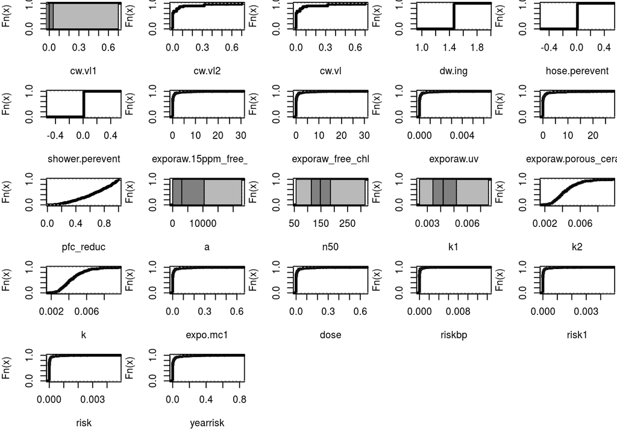

```r
# Plot the results.
plot(expo.ev1)
```

Report the mean and median of the exposure means with a 95% confidence interval (CI95).

```r
mean.expo <- sapply(1:ndunc(), function(j) mean(expo.ev1$expo.mc1[, j, ]))
mean(mean.expo)
```

```
## [1] 0.01120211
```

```r
quantile(mean.expo, probs = seq(0, 1, 0.025))[c("2.5%", "50%", "97.5%")]
```

```
##       2.5%        50%      97.5%
## 0.01120211 0.01120211 0.01120211
```

Report the mean and median of the DAILY risk probability means with a 95% confidence interval (CI95).

```r
mean.risk <- sapply(1:ndunc(), function(j) mean(expo.ev1$risk[, j, ]))
mean(mean.risk)
```

```
## [1] 4.992398e-05
```

```r
quantile(mean.risk, probs = seq(0, 1, 0.025))[c("2.5%", "50%", "97.5%")]
```

```
##         2.5%          50%        97.5%
## 4.388458e-05 4.979774e-05 5.603385e-05
```

Report the mean and median of the YEARLY risk probability means with a 95% confidence interval (CI95).

```r
mean.yearrisk <- sapply(1:ndunc(), function(j) mean(expo.ev1$yearrisk[, j, ]))
mean(mean.yearrisk)
```

```
## [1] 0.01581806
```

```r
quantile(mean.yearrisk, probs = seq(0, 1, 0.025))[c("2.5%", "50%", "97.5%")]
```

```
##       2.5%        50%      97.5%
## 0.01444342 0.01583765 0.01718496
```

Plot the empirical cumulative distribution function (ecdf) of the exposure model (`expo.mc1`) estimates.

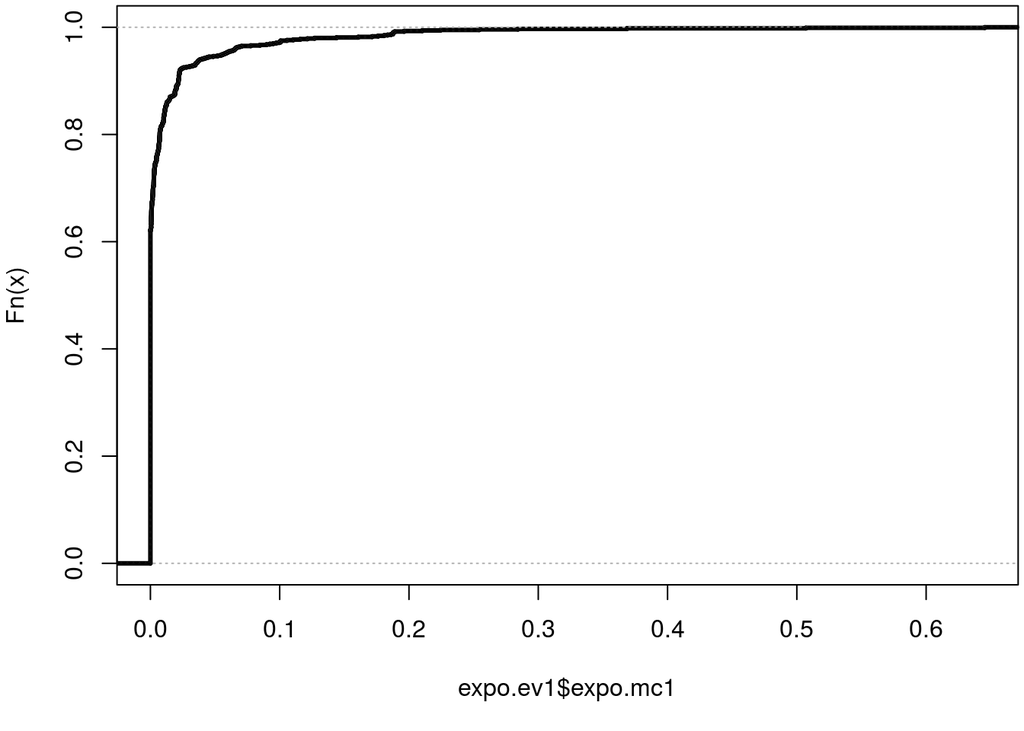

```r
# Generate an "ecdf" plot. This actually calls plot.mcnode().
plot(expo.ev1$expo.mc1)
```

Plot the empirical cumulative distribution function (ecdf) of the risk model (`risk`) estimates.

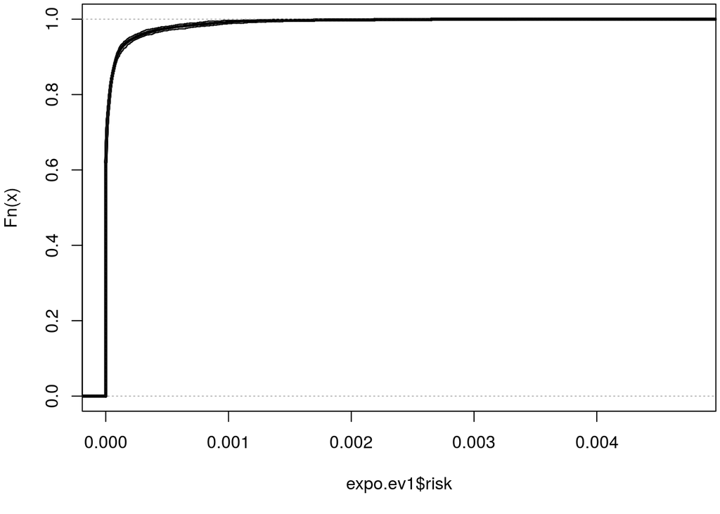

```r
# Generate an "ecdf" plot. This actually calls plot.mcnode().
plot(expo.ev1$risk)
```

Label the plot:

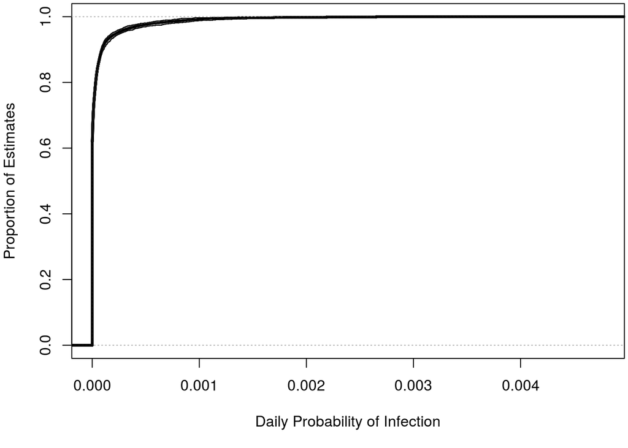

```r
# Generate an "ecdf" plot. This actually calls plot.mcnode().
plot(expo.ev1$risk, main = "", ylab = "Proportion of Estimates", xlab = "Daily Probability of Infection")
title("Daily Infec. Risk with Cryptosporidium by RCRW
in the USVI", cex.main = 1, font.main= 1, line = 7)
```

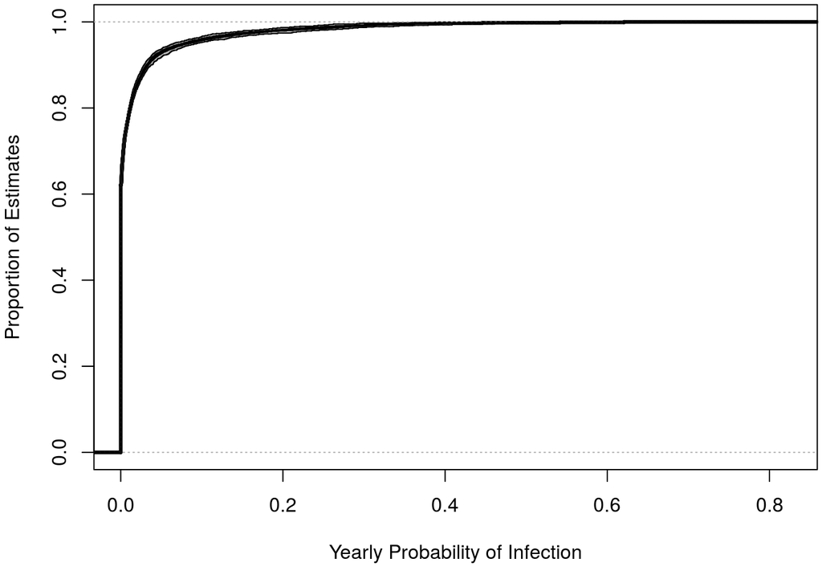

```r
# Generate an "ecdf" plot. This actually calls plot.mcnode().
plot(expo.ev1$yearrisk, main = "", ylab = "Proportion of Estimates", xlab = "Yearly Probability of Infection")
title("Yearly Infec. Risk with Cryptosporidium by RCRW
in the USVI", cex.main = 1, font.main= 1, line = 7)
```

Manually remake the graph, this time using yearrisk, which should just be another mcnode object with all values between 0 and 1:

The first one plots yearrisk without a log x scale:

```r
library(reshape)
```

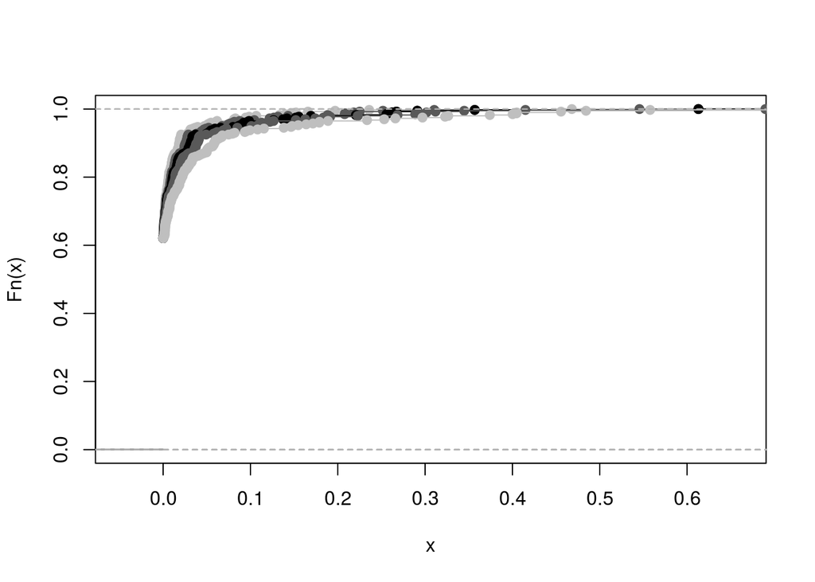

```r
library(ggplot2)
Risk.mat.1 <- expo.ev1$yearrisk[,,]
probs1 <- c(0.025, 0.25, 0.50, 0.75, 0.975)
quant1 <- as.data.frame(t(apply(Risk.mat.1, 1, quantile, probs = probs1)))
ecdfs1 <- sapply(names(quant1), function(q) ecdf(quant1[[q]]))
plot(ecdfs1[['50%']], main = '')
grays <- c('gray75', 'gray35', 'black', 'gray35', 'gray75')
lines <- mapply(function(e, g) lines(e, col = g), ecdfs1, grays)
```

Plotting yearrisk ECDF plot with ggplot2:

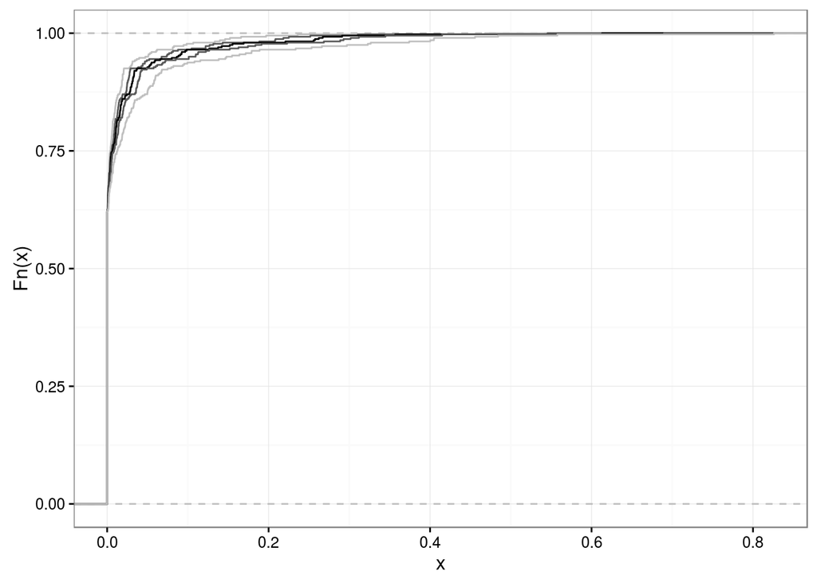

```r
quant.melt1 <- suppressMessages(melt(quant1))
names(quant.melt1) <- c('q', 'x')
grays <- c('gray75', 'gray35', 'black', 'gray35', 'gray75')
ggplot(quant.melt1, aes(x = x)) + theme_bw() + theme(legend.position = 'none') + geom_hline(yintercept = c(0, 1), linetype = "dashed", color = 'gray') + stat_ecdf(aes(group = q, color = q)) + xlab('x') + ylab('Fn(x)') + scale_colour_manual(values = grays)
```

Plot Version 2 with ggplot2, and a log-scale x axis:

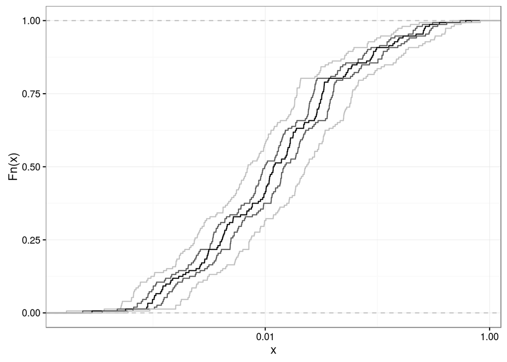

```r
quant.melt1 <- suppressMessages(melt(quant1))
names(quant.melt1) <- c('q', 'x')
grays <- c('gray75', 'gray35', 'black', 'gray35', 'gray75')
ggplot(quant.melt1, aes(x = x)) + theme_bw() + theme(legend.position = 'none') + geom_hline(yintercept = c(0, 1), linetype = "dashed", color = 'gray') + stat_ecdf(aes(group = q, color = q)) + xlab('x') + ylab('Fn(x)') + scale_colour_manual(values = grays) + scale_x_log10()
```